# Dona Rizqi Aulia

Dona Rizqi Aulia-Statistika dan Bisnis Muhammadiyah

2023-01-19

# Pengertian

Algoritma Iterative Dichotomiser 3 (ID3) ditemukan oleh J. Ross Quinlan th 1986 digunakan untuk menghasilkan pohon keputusan dari suatu dataset.

ID3 (Iterative Dichotomiser 3) merupakan salah satu metode dalam data mining yang arsitekturnya dengan pohon keputusan dibuat menyerupai bentuk pohon.

Dimana pada umumnya sebuah pohon terdapat akar (root), cabang yang hanya terdapat satu input dan min dua output dan daun (leaf node).

Pembentukan pohon klasifikasi dengan ID3 ada 2 Langkah, yaitu menghitung nilai entropy dan menghitung nilai information gain dari setiap variable.

# Thapan Algoritma ID3

1. Menyiapkan dataset
2. Menghitung Nilai Entropy
3. Menghitung nilai Gain
4. Membuat node cabang dari nilai gain yang terbesar
5. Proses perhitungan Information Gain terus dilakukan sampai semua data masuk kedalam kelas yang sama. Atribut yang telah dipilih tidak diikutkan lagi dalam nilai Information Gain.

# Eksperimen

```r
library(dplyr)
```

## Masukan Dataset

```r
library(readxl)
Data_penguin <- read_excel("~/ALGORITMA-ID3/Data penguin.xlsx")
View(Data_penguin)
```

Nilai Entropy pada setiap fitur/kolom dapat dihitung sebagai berikut:

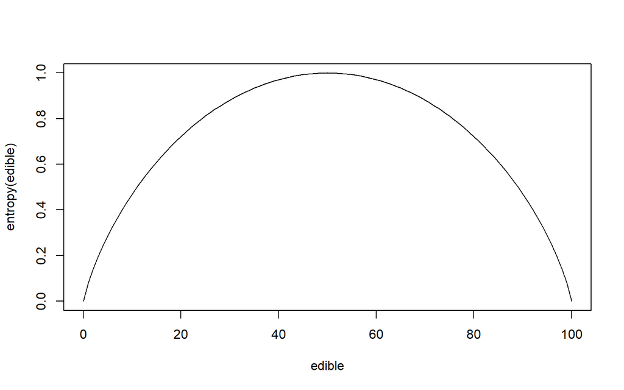

```r
IsPure <- function(data) {
  length(unique(data[,ncol(data)])) == 1
}
Entropy <- function( vls ) {
  res <- vls/sum(vls) * log2(vls/sum(vls))
  res[vls == 0] <- 0
  -sum(res)
}
entropy <- function(edible) Entropy(c(edible, 100 - edible))
entropy <- Vectorize(entropy)
curve( entropy, from = 0, to = 100, xname = 'edible')
```

Kemudian, berikut adalah bagaimana menghitung nilai Information Gain dari setiao fitur/kolom dalam suatu dataset

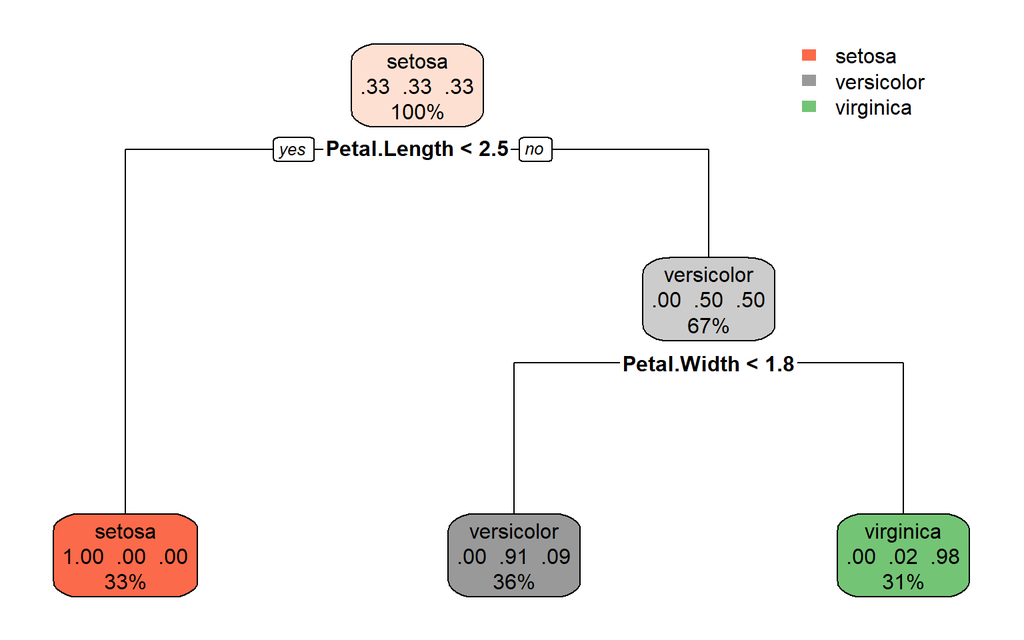

```r
library(rpart)
library(rpart.plot)
trees<-rpart(Species ~., data = iris, method = 'class')
rpart.plot(trees)
```

```r
InformationGain <- function( tble ) {
  tble <- as.data.frame.matrix(tble)
  entropyBefore <- Entropy(colSums(tble))
  s <- rowSums(tble)
  entropyAfter <- sum (s / sum(s) * apply(tble, MARGIN = 1, FUN = Entropy ))
  informationGain <- entropyBefore - entropyAfter
  return (informationGain)
}
```

```r
InformationGain(table(Data_penguin[,c('Culmen.Length', 'Species')]))
```

```
## [1] 1.15916
```

# Referensi

https://rpubs.com/philjet/shannonentropy https://victorzhou.com/blog/information-gain/ https://informatikalogi.com/algoritma-id3/